**Final Exam**

**HSE 545: Machine Learning**

|  | by Seungchul Lee |
| --- | --- |

# Problem 1

[data_files](https://www.dropbox.com/sh/ri8xc04pbnjmva7/AAB_6E5kTyHW_Il-gcrQsstXa?dl=0)

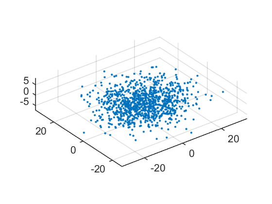

```
Name         Size            Bytes  Class     Attributes

  data      1000x3             24000  double
```

```matlab
clear all
load([pwd,'\image_files\iSystems_P01_data.mat'])
whos

m = 1000;
scatter3(data(:,1),data(:,2),data(:,3),'.')
axis equal
```

1) [3pt] Suppose you know that this set of data is generated from the multivariate Gaussian distribution whose mean vector and covariance matrix are unknown. Find the MLE for mean and covariance matrix from the given observations.

```matlab
%% MLE for mean and covariance from m obervations

%%%%%%%%%%%%%%%%%%%%%%%%%
% complete your code here
%%%%%%%%%%%%%%%%%%%%%%%%%
```

2) [5pt] Apply SVD on a sample covariance matrix and plot the singular values. Explain how the singular values can be interpreted in terms of dimension reduction.

```matlab
%% dim reduction

%%%%%%%%%%%%%%%%%%%%%%%%%
% complete your code here
%%%%%%%%%%%%%%%%%%%%%%%%%
```

3) [5pt] Suppose you conduct a low rank approximation using the result from 2). Compute the sample covariance matrix of the dimension-reduced data set.

```matlab
%% Low rank approximation

%%%%%%%%%%%%%%%%%%%%%%%%%
% complete your code here
%%%%%%%%%%%%%%%%%%%%%%%%%
```

# Problem 2

[10pt] Compute PageRank of each node.

[figure not shown]

```matlab
%%%%%%%%%%%%%%%%%%%%%%%%%
% complete your code here
%%%%%%%%%%%%%%%%%%%%%%%%%
```

# Problem 3

[data_files](https://www.dropbox.com/sh/ri8xc04pbnjmva7/AAB_6E5kTyHW_Il-gcrQsstXa?dl=0)

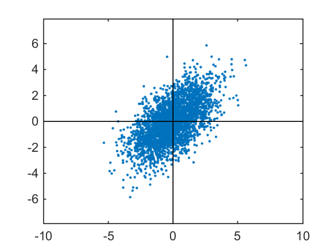

```
Name         Size            Bytes  Class     Attributes

  x         3000x2             48000  double
```

```matlab
%plot -s 560,420
load([pwd,'\image_files\iSystems_P03_data.mat'])
whos x
plot(x(:,1),x(:,2),'.'), hold on
axis equal, xlim([-10,10])
h1 = line([0 0], ylim);
h2 = line(xlim,[0 0]); hold off
set(h1,'Color','k')
set(h2,'Color','k')
```

1) [8pt] Write a m-code to find a linear transformation $y = Ax$ such that $y$ are uncorrelated (or independent).

```matlab
%%%%%%%%%%%%%%%%%%%%%%%%%
% complete your code here
%%%%%%%%%%%%%%%%%%%%%%%%%
```

2) [2pt] Plot $y$

```matlab
%%%%%%%%%%%%%%%%%%%%%%%%%
% complete your code here
%%%%%%%%%%%%%%%%%%%%%%%%%
```

# Problem 4

1. [2pt] Write down the definitions of MLE and MAP. Indicate a prior, a posterior, and likelihood.
2. [3pt] Explain how MAP and MLE are different, and their relationship using the Bayes rule.
3. [5pt] When do you think MLE and MAP are the same ?
4. [5pt] Consider a set of data generated from the Gaussian distribution $N(\mu,\sigma^2)$ where mean $\mu$ is unknown. Show MLE of mean is identical to a sample mean.
5. [5pt] Sample mean $\bar x$ can be seen as an expectation of random variable $x$ with a uniform distribution.
   $$ \bar x = \frac{1}{m}\sum_{i=1}^{m} x_i = \sum_{i=1}^{m} \frac{1}{m}x_i \;\; \text{and}\;\; E[x] = \sum_{i=1}^{m} P(x_i)x_i$$
   If you do not have any prior information on the given random variable, what is the most reasonable (or fair) probability distribution that you can assume ? In addition, describe how your answer is related to yours in 3).

# Problem 5

[10pt] In a heads or tails coin-tossing experiment the probability of occurrence of a head (1) is $q$ and that of a tail (0) is $1-q$. Let $x_i, \, i=1,2,\cdots,m$ be the resulting experimental outcomes, $x_i \in \{0,1\}$, Show that the ML estimate of $q$ is

$$q_{\text{ML}} = \frac{1}{m} \sum_{i=1}^{m}x_i$$

Hint: The likelihood function is

$$P(x_1 x_2 \cdots x_m \mid q) = \prod_{i=1}^{m} q^{x_i}(1-q)^{1-x_i}$$

# Problem 6

We showed that if the likelihood function is Gaussian with unknowns, the mean $\mu$ as well as the covariance matrix $\Sigma$, then the ML estimates are given by

$$ \begin{align*} \hat \mu_m & = \frac{1}{m} \sum_{i =1}^{m} x_i \\ \hat \Sigma_m & = \frac{1}{m} \sum_{i=1}^{m} (x_i - \hat \mu_m)(x_i - \hat \mu_m)^T \end{align*} $$

1) [10pt] Show that the ML estimates of the mean value and the covariance matrix can be computed *recursively*, that is,

$$ \begin{align*} \hat \mu_{m+1} &= \hat \mu_m + \frac{1}{m+1} (x_{m+1} - \hat \mu_m)\\ \hat \Sigma_{m+1} & = \frac{m}{m+1} \hat \Sigma_m + \frac{m}{(m+1)^2} (x_{m+1} - \hat \mu_m)(x_{m+1} - \hat \mu_m)^T \end{align*} $$

2) [2pt] Explane why such a recurive method is important when the estimates are implemented.

# Problem 7

[10pt] Middle East Respiratory Syndrome (MERS) outbreaked in South Korea, which caused extremely serious problems to almost every corner of our societies. Read the following conversation regarding MERS.

**A**: All the media in Korea talk about MERS nowadays. It is getting more serious. I do not think that Ulsan is a safe place any more. I think I should go and get some masks to be protected from MERS. Do you want to go with me?

**B**: Mask? Are you kidding? On the hottest day like today? I do not want to wear a mask. By the way, I remember that the World Health Organization said "the risk of sustained person-to-person transmission appears to be very low."

**A**: I know that, but I am afraid that there is potential danger in that it is possible for the virus to mutate into a strain that does transmit from person to person. I believe that more evidences that support this are coming on the news. Look at this news article!

**B**: I also heard those news from TV. However, some are just rumors!!! Anyway, I am not going with you.

From the above conversations between **A** and **B**, we can find out that they behave differently although they have had the similar amount of information and heard similar news. Explain why they end up drawing different conclusions using the concept of MAP.

$$\theta_{\text{MAP}} = \frac{m}{m+\sigma^2} \bar x + \frac{\sigma^2}{m+\sigma^2} \mu$$

# Problem 8

Suppose there are 19 hypotheses ($H_i$) and 16 evidences ($E_j$). You can think of hypothesis and evidence as cause and symptoms, respectively. Each element in either Table 2 or matrix A represents a conditional probability $a_{ij} = P(E_j \mid H_i)$. Furthermore, if you read the matrix in a row direction, it is a probability mass function of $P(E \mid H_i)$ and $\sum_{j=1}^{16}P(E_j \mid H_i) = 1$ for $i=1,\cdots,19$. However, if you read the matrix in a column direction, it is a probability mass function of $P(E_j \mid H)$ and $\sum_{i=1}^{19} P(E_j \mid H_i) \neq 1$ for $j=1,\cdots, 16$. Here, we want to determine the most probable hypothesis given multiple evidences in this problem. For example, hypothesis $H_1$ generates evidence $E_1$ with probability 0.0297, evidence $E_2$ with probability 0.0139, and so on. After observing several evidences, the question is which hypothesis the most likely one is. Make your own assumptions on unspecified probabilities if necessary. For example, probability $P(H_i)$ can be treated as a prior.

|  | $E_1$ | $E_2$ | $E_3$ | $\cdots$ | $E_{16}$ |
| --- | --- | --- | --- | --- | --- |
| $H_1$ | 0.0297 | 0.0139 | 0.0940 | $\cdots$ | 0.0024 |
| $H_2$ | 0.0297 | 0.0139 | 0.0478 | $\cdots$ | 0.0024 |
| $H_3$ | 0.0297 | 0.0139 | 0.0913 | $\cdots$ | 0.0024 |
| $\vdots$ | $\vdots$ | $\vdots$ | $\vdots$ | $\cdots$ | $\vdots$ |
| $H_{19}$ | 0.0297 | 0.0139 | 0.0695 | $\cdots$ | 0.2296 |

$$ A = \begin{bmatrix} 0.0297 & 0.0139 & 0.0940 & \cdots \\ 0.0297 & 0.0139 & 0.0478 & \cdots \\ 0.0297 & 0.0139 & 0.0913 & \cdots \\ \vdots & \vdots & \vdots & \cdots \end{bmatrix}$$

1. [2pt] Formulate this problem as a MAP problem from the available information.
   $$ \text{arg}\max_{H} P(H \mid E)$$
2. [3pt] With an assumption of conditional independency of evidences, show how to compute the following probability from the available information.
   $$ \text{arg}\max_{H} P(H \mid E_i \cdots E_k)$$
   (hint: multiple evidences and recursive Bayesian estimation)
3. [10pt] What is the most probable hypothesis, given two evidences $E_1$ and $E_{10}$ ? Use the following m-file template. Plot $P(H \mid E_{1} E_{10})$ for all H.

$$ \text{arg}\max_{H} P(H \mid E_{1} E_{10})$$

[data_files](https://www.dropbox.com/sh/ri8xc04pbnjmva7/AAB_6E5kTyHW_Il-gcrQsstXa?dl=0)

```matlab
%% load matrix A
load([pwd,'\image_files\iSystems_P08_matrix.mat']);
whos A
```

```
Name       Size            Bytes  Class     Attributes

  A         19x16             2432  double
```

```matlab
%%%%%%%%%%%%%%%%%%%%%%%%%
% complete your code here
%%%%%%%%%%%%%%%%%%%%%%%%%
```

# Problem 9

1) [3pt] show that a decision boundary between two classes in the Bayesian classifier can be expressed as the following equation:
$$ F(x) = \log \frac{P(x \mid y=0)P(y=0)}{P(x \mid y = 1)P(y=1)} = 0 $$
2) [5pt] Suppose two classes follow Gaussian distributions with different means and equal variance. Show that a decision boundary is linear in $\mathbb{R}^n$.
3) [5pt] Suppose two classes follow Gaussian distributions with different means and unequal variances. Show that a decision boundary is quadratic in $\mathbb{R}^n$.

4) [10pt] With two classes of data from Gaussian distributions with equal variance, complete a m-code to draw the linear decision boundary in $\mathbb{R}^2$.

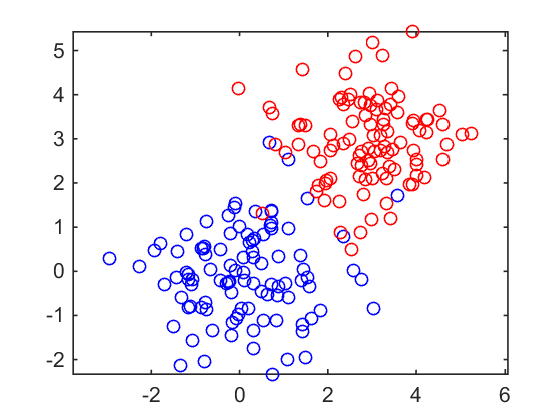

```matlab
% Equal variance
clear all
ndata = 100;    % # of samples

% given equal sigma and mu1, mu2
sigma = eye(2);
mu1 = [0 0]';
mu2 = [3 3]';

% prior
q1 = 0.5;
q2 = 0.5;

% data generation from Gaussian
class1 = mvnrnd(mu1,sigma,ndata);
class2 = mvnrnd(mu2,sigma,ndata);

% plot
plot(class1(:,1),class1(:,2),'bo'), hold on
plot(class2(:,1),class2(:,2),'ro'), hold off
box on, axis equal
```

```matlab
%% F = w'x + w0
%%%%%%%%%%%%%%%%%%%%%%%%%%%%%%%%%%%
% fill out here to compute w and w0
%%%%%%%%%%%%%%%%%%%%%%%%%%%%%%%%%%%
```

```matlab
%% to plot
x1 = linspace(-3,6);
x2 = linspace(-3,6);
[X1,X2] = meshgrid(x1,x2);
F = w(1)*X1 + w(2)*X2 + w0;
plot(class1(:,1),class1(:,2),'bo'), hold on
plot(class2(:,1),class2(:,2),'ro')
contour(X1,X2,F,[0 0]), hold off
box on, axis equal, xlim([-2,6])
```

5) [10pt] Generate two classes of data from Gaussian distributions with unequal variance. Complete a m-code to draw the quadratic decision boundary in $\mathbb{R}^2$.

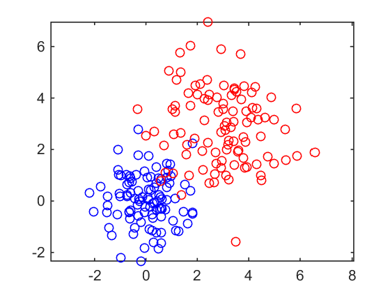

```matlab
%% Unequal variance
clear all
ndata = 100;
sigma1 = eye(2);
sigma2 = 2*eye(2);
mu1 = [0 0]';
mu2 = [3 3]';
q1 = 0.5;
q2 = 0.5;
class1 = mvnrnd(mu1,sigma1,ndata);
class2 = mvnrnd(mu2,sigma2,ndata);
% plot
plot(class1(:,1),class1(:,2),'bo'), hold on
plot(class2(:,1),class2(:,2),'ro'), hold off
box on, axis equal
```

```matlab
%% F = x'Wx + w'x + w0
%%%%%%%%%%%%%%%%%%%%%%%%%%%%%%%%%%%%%%
% fill out here to compute W, w and w0
%%%%%%%%%%%%%%%%%%%%%%%%%%%%%%%%%%%%%%
```

```matlab
%% to plot
x1 = linspace(-5,8);
x2 = linspace(-5,8);
[X1,X2] = meshgrid(x1,x2);
F = W(1,1)*X1.^2 + W(2,2)*X2.^2 + 2*W(1,2)*X1.*X2 + w(1)*X1 + w(2)*X2 + w0;
plot(class1(:,1),class1(:,2),'bo'), hold on
plot(class2(:,1),class2(:,2),'ro')
contour(X1,X2,F,[0 0]), hold off
box on, axis equal, xlim([-4,7])
```